# Medindo a diversidade funcional

A diversidade funcional vem se destacando como uma das mais promissoras maneiras de se medir a diversidade biológica, por incorporar traços funcionas que possuem algum valor ecológico e que possuem alguma importância na manutenção dos serviços ecossistêmicos. Sendo assim, a proposta discutida por (Villéger, Mason, and Mouillot 2008) é de utilizar três índices independentes e complementares para descrever a diversidade funcional de uma determinada comunidade.

Os índices são:

1. **Functional Richness (Frich)**
2. **Functional Evenness (Feven)**
3. **Functional Divergence (Fdiv)**

#### Considerções sobre a escolha dos traços funcionais

A escolha dos traços funcionais são de extrema importância para a descrição da diversidade funcional de uma comunidade, buscando evitar redundância entre os mesmos. As análises a seguir suportam tanto dados quantitativos (peso, altura, comprimento e etc.), como qualitativos (cor, sexo, estágio de desenvolvimento e etc.).

#### Breve explicação dos índices

Levando em conta que o Nicho funcional possui T dimensões definidas por T eixos, cada eixo defino por cada traço funcional, a riqueza funcional de uma comunidade *(Frich)* pode ser calculada como o espaço preenchido por determinada comunidade. Cada espécie representa um ponto no espaço, assim estima-se o volume preenchido no espaço T dimensional. A uniformidade funcional *(Feven)* pode ser entendida como a regularidade com que o espaço é preenchido pelas espécies, esse índice vai de 0 a 1, sendo que 1 representa uma comunidade onde as espécies estão todas equidistantes no plano funcional. Por fim, a divergência funcional *(Fdiv)* refere-se a quão divergentes as espécies são dentro de uma comunidade. Esse índice também varia de 0 a 1, sendo que 1 representa quando as espécies mais abundantes estão distantes do “centro de gravidade” do espaço funcional.

Para maiores detalhes sobre os índices funcionais consultar *Velligér et al.(2008)*

### Calculando índices de diversidade funcional

Para isso será necessário utilizar os seguintes pacotes:

```r
require(FD)
require(tidyverse)
```

#### Objetos utilizados

Para calcular os índices de diversidade funcional é necessário 2 objetos, (1) contendo as variáveis funcionais nas colunas e as espécies e (2) contendo a abundância das espécies em cada comunidade. Para isso iremos utilizar os dados presentes no pacote `FD`

```r
data("dummy") #carregar dados

dummy$trait # traços morfológicos
```

```
##     num1 num2 fac1 fac2 ord1 ord2 bin1 bin2
## sp1  9.0  4.5    A    X    3    2    0    1
## sp2  8.1  6.0    A    Z <NA>    1    0    1
## sp3   NA  2.3    C    Y    5    3    1    1
## sp4  3.2  5.4    B    Z    1    7    0    0
## sp5  5.8  1.2    C    X    2    6   NA    0
## sp6  3.4  8.5    C    Y    2    1    1    1
## sp7  7.5  2.1    B    X    3    2    1    0
## sp8  4.3  6.5 <NA>    Z    1    3    0    1
```

```r
dummy$abun #matriz de abundância
```

```
##       sp1 sp2 sp3 sp4 sp5 sp6 sp7 sp8
## com1    1   1   0   0   4   2   0   0
## com2    0   0   0   2   1   0   0   5
## com3    2   0   0   0   0   1   0   3
## com4    1   0   7   0   0   0   0   0
## com5    0   0   2   3   3   0   0   0
## com6    0   3   0   0   5   6   1   6
## com7    3   5   0   3   0   0   0   0
## com8    0   0   0   0   6   2   1   2
## com9    4   1   1   3   0   0   2   0
## com10   0   4   1   0   0   0   6   1
```

#### Função `dbFD()`

Essa função permite calcular de uma única vez os três índices descritos anteriormente.

```r
ex1<-dbFD(dummy$trait, dummy$abun)
```

```r
ex1$FRic # Functional Richness
```

```
##        com1        com2        com3        com4        com5        com6
## 0.174201349 0.102097174 0.002157642          NA 0.143151204 0.231083703
##        com7        com8        com9       com10
## 0.073683375 0.174220613 0.337446205 0.228904118
```

```r
ex1$FEve #Functional Evenness
```

```
##      com1      com2      com3      com4      com5      com6      com7      com8
## 0.8432334 0.4628635 0.8659657        NA 0.9081209 0.8651734 0.7681991 0.7606650
##      com9     com10
## 0.7994638 0.4944601
```

```r
ex1$FDiv #Functional Divergence
```

```
##      com1      com2      com3      com4      com5      com6      com7      com8
## 0.8429221 0.8593250 0.6303031        NA 0.7631346 0.8966687 0.8356095 0.8681163
##      com9     com10
## 0.7015118 0.9712554
```

Podemos representar visualmente a riqueza funcional *(Frich)* da seguinte maneira:

```r
trait.d <- gowdis(dummy$trait) #Calcular uma medida de distância
nmds<- metaMDS(trait.d) #utilizar uma análise de ordenação

##criar data.frame com os valores da ordenação
MDS1<- nmds$points[,1]
MDS2<- nmds$points[,2]
nmds<- data.frame(MDS1 = MDS1, MDS2 = MDS2)

#calculando volume do espaco funcional
hull <- nmds %>%
  slice(chull(MDS1, MDS2))
```

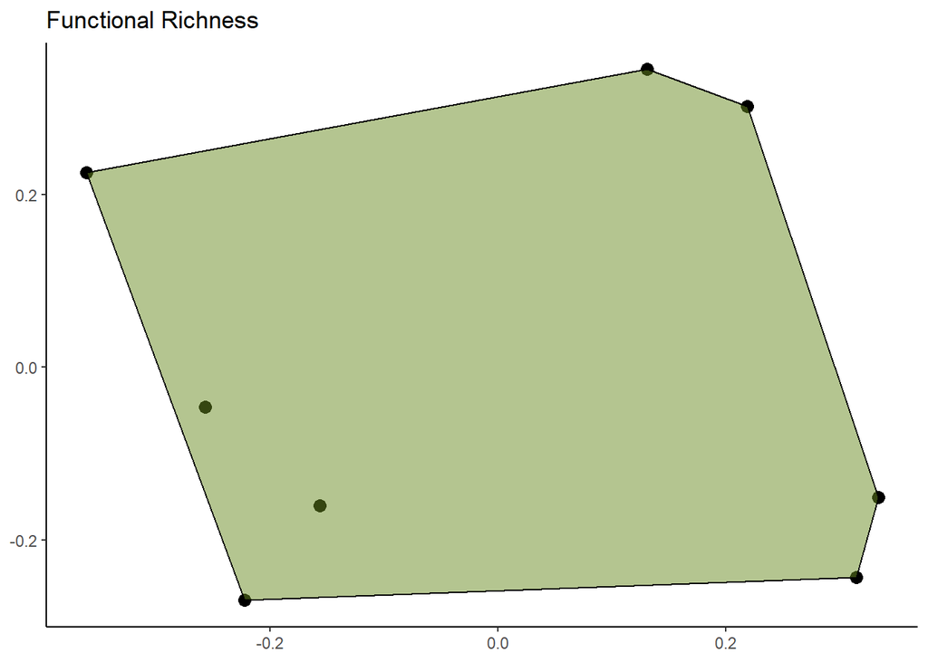

```r
#Plotando o gráfico
ggplot(nmds, aes(x=MDS1,y=MDS2)) + geom_point(size=3)  + geom_polygon(data = hull, alpha = 0.5,col= "black", fill = "olivedrab4")+ theme_classic() + labs(title = "Functional Richness",x = NULL, y = NULL)
```

Com esses três índices é possível traçar um melhor panorama da comunidade e identificar mudanças ao longo do espaço e/ou tempo.

Qualquer dúvida, correção ou sugestão pode ser encaminhada para gfellipe5@gmail.com

#### Referências

Villéger, Sébastien, Norman WH Mason, and David Mouillot. 2008. “New Multidimensional Functional Diversity Indices for a Multifaceted Framework in Functional Ecology.” *Ecology* 89 (8). Wiley Online Library: 2290–2301.